# MSDA Workshop 1

Student Handout

Brent Halen

February 11, 2016

# Part 1 : Programming Basics

Programming Basics: - Primitive Data Types - Data Formats - Operations - Statements - Declarations - Assignments - Conditional - Loops

## Programming/Computer Science

- We will be using R.
- R is very heavily used in the MSDA program.
- Not the best language to demonstrate all of the CS concepts we’ll cover today.
- We’re going to cover three components of computer programs:
- Data Types
- Operations
- Statements.

## Primitive Data Types

There are four primitive data types: Integers, Real Numbers, Booleans, and Characters.

1. Integers are your basic numbers without decimals.
   - 1, 2, 3, 4, 999, and such.
   - Integers cannot be divided into quantities less than 1.
2. Numeric data values are numbers with decimal points.
   - 3.14159 is a Numeric data type.
3. Logical (Often called Boolean in other languages) is a data type that reads either ‘TRUE’ or ‘FALSE’. -This is going to be important for when we go over loops and conditionals.
4. Characters are letters, numbers, and symbols that are read as text.
   - A collection of characters can be stored as a “string”.

## Data Formats

1. R can store these basic data types in multiple formats, some dependent upon the various packages used. For the basics, you mainly need to remember these: Vectors, Lists, Matrixes, Arrays, and Data Frames.
2. Vectors and lists are very similar.
   - Both are one-dimensional data storage types.
   - The difference is that the members of a vector are all of the same basic data type.
   - Lists can be composed of multiple data types, even other lists.
3. In the same way, matrixes and data frames are very similar.
   - Both are two-dimensional data storage types.
   - You could think of data frames as a storage type for multiple vectors.
   - A matrix must have the same data type along all of its vectors while a data frame can have different data types for each vector/columns.

   ```
   However, you cannot mix and match data types within vectors/columns.
   ```

4. An array is like a matrix, but it can take any number of dimensions.

```
We'll cover these in more detail when we get to statements.
```

## Operations

The following operations can be performed on integers and numeric.

```r
#Addition
6 + 9
```

```
## [1] 15
```

```r
#Subtraction
7 - 12
```

```
## [1] -5
```

```r
#Multiplication
8.543 * 4.65
```

```
## [1] 39.72495
```

```r
#Division
4 / 3
```

```
## [1] 1.333333
```

```r
# Raised to a power
2 ^ 8
```

```
## [1] 256
```

```r
# Modulo (think 'remainder' from grade school math days).
7 %% 2
```

```
## [1] 1
```

```r
# Integer division (the other half of the 'modulo' operation.)
# (Basically, how many times y will fit into x without resorting to the use of decimal points.)
7 %/% 2
```

```
## [1] 3
```

## Operations (cont.)

The following operations can be done to return boolean data types.

```r
c <- 1
d <- 2
# Is equal to
c == d
```

```
## [1] FALSE
```

```r
# Is not equal to
c != d
```

```
## [1] TRUE
```

```r
# Is less than
c < d
```

```
## [1] TRUE
```

```r
# Is less than or equal to
c <= d
```

```
## [1] TRUE
```

```r
# Is greater than
c > d
```

```
## [1] FALSE
```

```r
# Is greater than or equal to
c >= d
```

```
## [1] FALSE
```

```
Note:
The '!' character is a logical negation, applicable to any boolean.
```

## Operations (cont.)

The following operations can be performed on booleans for more complex statements. Each one of these operations takes two boolean operators and returns another.

```r
a <- TRUE
b <- FALSE
# and (elementwise)
a & b
```

```
## [1] FALSE
```

```r
# and (evaluates left-to-right examining only the first element of each vector)
a && b
```

```
## [1] FALSE
```

```r
# or (elementwise)
a | b
```

```
## [1] TRUE
```

```r
# or (evaluates left-to-right examining only the first element of each vector)
a || b
```

```
## [1] TRUE
```

```
Note:
The longer version of && and || is usually the one you want to use in 'control statements', which we'll cover in the next section.
```

## Statements

1. Every line of code in R can be described as a ‘statement’.
2. We’re going to categorize the statements into the following 5 groups:
   - Declarations
   - Assignments
   - Conditionals
   - Loops
   - Calls/Returns.

## Declarations

```r
testvar <- integer()
```

3. It creates an integer variable under the name ‘testvar’.

```
Note: In some programming languages, you are required to declare a variable before you can assign it a value. Usually, this is because those languages have more options with regards to memory management, so you have to be more specific about how to manage memory. C++ and Java are a couple of examples of this. R automates more of this process, so you can often just use an assignment statement to declare your variable at the same time.
```

## Assignment

1. Assignment statements assign a value to a variable.
2. The following line of code is an assignment statement:

```r
testvar <- 6
```

```
- It assigns the integer value 6 to our 'testvar' variable.
```

3. Now, there are also what they call ‘initializing declarations’, where the variable is declared and assigned a value in one line of code.
   - The next line of code is an example of this.

```r
a <- 6
```

[output not shown]

## Conditional (Logical/Boolean)

1. A conditional statement is a line of code that will only execute if a specified Boolean returns TRUE.
   - The following line of code will check to see if c is less than d.
   - If TRUE, it will assign a the sum of c and d to a new variable ‘e’.

```r
if(c < d){ e <- c + d }
```

2. Let’s enter ‘e’ into the console to see if our code worked.

```r
e
```

```
## [1] 3
```

## Conditional (cont.)

3. You can use ‘else if’ and ‘else’ to specify more complicated conditional statements.

```r
if(e < 3){
    e <- 3
} else if (e > 3) {
    e <- 4
} else {
    e <- 2
}
```

4. You can put as many ‘else if’ extensions as you want, but you can only use one ‘else’.

## Loops

1. Loops are similar to conditionals in that they run code based on a specified condition (usually a boolean).
   - The difference is that they will repeat the nested code until the specified condition no longer applies.
   - The two kinds of loops we will cover are “for” and “while” loops.
2. A ‘for’ loop uses the following format:

```r
a <- c(1, 2, 3, 4, 5, 6, 7, 8, 9, 10) # Declare a 10-member vector.
for(i in 1:10){
  b <- a[i]^2
  print(b)
}
```

```
## [1] 1
## [1] 4
## [1] 9
## [1] 16
## [1] 25
## [1] 36
## [1] 49
## [1] 64
## [1] 81
## [1] 100
```

```
- This will print the squared values of each member of the vector.
- This saves us time as we don't need to explicitly write code for squaring each value.
```

```
Note:
If you encounter an error during your loop, the loop will fail. A common error is to call an index outside of the range of the object you're examining, say if you call item 11 in a 10-item vector. One way to get around this is to use the 'length()', 'nrow()', and 'ncol()' functions.
```

3. A ‘while’ loop will take a boolean and repeat until the condition returns FALSE.
   - An example of a ‘while’ loop:

```r
a <- 0
while(a < 10){
  a <- a + 1
  print(a)
}
```

```
## [1] 1
## [1] 2
## [1] 3
## [1] 4
## [1] 5
## [1] 6
## [1] 7
## [1] 8
## [1] 9
## [1] 10
```

```
- The code should output 1 through 10. If you call 'a' from the command line now, it will return a value of 10.
```

```
Note:
Keep in mind that a while loop will not trigger if the initial Boolean passed to the 'while' function is already FALSE. To make sure a loop iterates at least once, look for information on the 'Repeat' loop.
```

## Calls/Returns

1. A call is when you invoke a function. An example of this would be when you typed ‘integer()’ earlier.
- When you typed ‘integer()’, you didn’t include anything in the parentheses. This is where you put the ‘Arguments’ of the function you’re trying to call.
- We’ll see this more clearly when we start defining functions in the next section.
2. A return statement tells a function to ‘return’ a particular value.
- It helps to think of this as the funciton “spitting back” a result.
- When you called ‘integer()’ earlier, it “returned” an empty integer data type.
- When you define functions, you will determine whether or not you want that function to return a value with the ‘return()’ command.

# Part 2: Using R

Using R:

1. Defining a function
2. Downloading Data from a URL
3. Manipulating our Data
4. Sourcing .R files
5. Notes
6. How to install/load packages in R
7. dplyr
- “Piping” (%>%) operator.
- “mutate()” command.
8. caret
- Create a training & test set.
- Train a model with the ‘train()’ function.
- Measuring model performance.

## Defining Functions

```
Now that the fundamentals are out of the way, let's get to using R itself.
```

1. First, we’re going to define an R function.
   - This function will take a value we assign to it, run code on it, and return the result.

```r
a <- 45
squaremod <- function(x){
  x <- x^2
  x <- x %/% 2
  return(x)
}
squaremod(a)
```

```
## [1] 1012
```

```
- This function should return a value of 1012.
```

2. Because it returns a value, we can call the function and assign the value to a variable.
   - Example:

```r
squaremod(37)
```

```
## [1] 684
```

```r
g <- squaremod(37)
print(g)
```

```
## [1] 684
```

### Downloading Data from a URL

1. Now, we’re going to download a dataset. Luckily, R can download data directly from the internet. This is a data set from an old Kaggle competition that I’m hosting on my Github.

```r
Url <- "https://raw.githubusercontent.com/brent-halen/MSDA_Workshops/master/Introduction_to_R/Data/train.csv"
download.file(url = Url, destfile = "titanic.csv")
titanic <- read.csv(file="titanic.csv",header=TRUE)
```

2. Let’s take a look at our data using the ‘str’ command.

```r
str(titanic)
```

```
## 'data.frame':    891 obs. of  12 variables:
##  $ PassengerId: int  1 2 3 4 5 6 7 8 9 10 ...
##  $ Survived   : int  0 1 1 1 0 0 0 0 1 1 ...
##  $ Pclass     : int  3 1 3 1 3 3 1 3 3 2 ...
##  $ Name       : Factor w/ 891 levels "Abbing, Mr. Anthony",..: 109 191 358 277 16 559 520 629 417 581 ...
##  $ Sex        : Factor w/ 2 levels "female","male": 2 1 1 1 2 2 2 2 1 1 ...
##  $ Age        : num  22 38 26 35 35 NA 54 2 27 14 ...
##  $ SibSp      : int  1 1 0 1 0 0 0 3 0 1 ...
##  $ Parch      : int  0 0 0 0 0 0 0 1 2 0 ...
##  $ Ticket     : Factor w/ 681 levels "110152","110413",..: 524 597 670 50 473 276 86 396 345 133 ...
##  $ Fare       : num  7.25 71.28 7.92 53.1 8.05 ...
##  $ Cabin      : Factor w/ 148 levels "","A10","A14",..: 1 83 1 57 1 1 131 1 1 1 ...
##  $ Embarked   : Factor w/ 4 levels "","C","Q","S": 4 2 4 4 4 3 4 4 4 2 ...
```

3. This returns a general summary of our data frame: What data type it is, what data type the different columns are, the name of each column, etc.

```
Note:
This allows us to introduce another data type in R: 'factor'. This is the equivalent of 'categorical' data in R. Each unique entry in the column is assigned a 'level'. This is useful when you need to model data using categorical input values (like 'male' vs 'female', 'red' vs 'blue' vs 'green', etc.).
```

### Manipulating our Data

1. Let’s say we don’t want to have our data coerced into factors.
   - We need to modify our original code above and pass a ‘stringsAsFactors == FALSE’ argument to the read.csv() argument.

```r
titanic <- read.csv(file="titanic.csv",header=TRUE,stringsAsFactors = FALSE)
str(titanic)
```

```
## 'data.frame':    891 obs. of  12 variables:
##  $ PassengerId: int  1 2 3 4 5 6 7 8 9 10 ...
##  $ Survived   : int  0 1 1 1 0 0 0 0 1 1 ...
##  $ Pclass     : int  3 1 3 1 3 3 1 3 3 2 ...
##  $ Name       : chr  "Braund, Mr. Owen Harris" "Cumings, Mrs. John Bradley (Florence Briggs Thayer)" "Heikkinen, Miss. Laina" "Futrelle, Mrs. Jacques Heath (Lily May Peel)" ...
##  $ Sex        : chr  "male" "female" "female" "female" ...
##  $ Age        : num  22 38 26 35 35 NA 54 2 27 14 ...
##  $ SibSp      : int  1 1 0 1 0 0 0 3 0 1 ...
##  $ Parch      : int  0 0 0 0 0 0 0 1 2 0 ...
##  $ Ticket     : chr  "A/5 21171" "PC 17599" "STON/O2. 3101282" "113803" ...
##  $ Fare       : num  7.25 71.28 7.92 53.1 8.05 ...
##  $ Cabin      : chr  "" "C85" "" "C123" ...
##  $ Embarked   : chr  "S" "C" "S" "S" ...
```

2. Notice how the ‘Factor’ columns have now changed to ‘chr’ columns.
   - Of course, we might want to set some of them to factors or even make other changes to the data types.
   - R allows the user to call a single column as a vector by the column name.

```r
titanic$Sex
```

```
##   [1] "male"   "female" "female" "female" "male"   "male"   "male"
##   [8] "male"   "female" "female" "female" "female" "male"   "male"
##  [15] "female" "female" "male"   "male"   "female" "female" "male"
##  [22] "male"   "female" "male"   "female" "female" "male"   "male"
##  [29] "female" "male"   "male"   "female" "female" "male"   "male"
##  [36] "male"   "male"   "male"   "female" "female" "female" "female"
##  [43] "male"   "female" "female" "male"   "male"   "female" "male"
##  [50] "female" "male"   "male"   "female" "female" "male"   "male"
##  [57] "female" "male"   "female" "male"   "male"   "female" "male"
##  [64] "male"   "male"   "male"   "female" "male"   "female" "male"
##  [71] "male"   "female" "male"   "male"   "male"   "male"   "male"
##  [78] "male"   "male"   "female" "male"   "male"   "female" "male"
##  [85] "female" "female" "male"   "male"   "female" "male"   "male"
##  [92] "male"   "male"   "male"   "male"   "male"   "male"   "male"
##  [99] "female" "male"   "female" "male"   "male"   "male"   "male"
```

[output cut: 113 more lines]

```
- This allows us to pass the columns to a function and assign the result to a column of the dataframe.
```

```r
titanic$Sex <- as.factor(titanic$Sex)
str(titanic)
```

```
## 'data.frame':    891 obs. of  12 variables:
##  $ PassengerId: int  1 2 3 4 5 6 7 8 9 10 ...
##  $ Survived   : int  0 1 1 1 0 0 0 0 1 1 ...
##  $ Pclass     : int  3 1 3 1 3 3 1 3 3 2 ...
##  $ Name       : chr  "Braund, Mr. Owen Harris" "Cumings, Mrs. John Bradley (Florence Briggs Thayer)" "Heikkinen, Miss. Laina" "Futrelle, Mrs. Jacques Heath (Lily May Peel)" ...
##  $ Sex        : Factor w/ 2 levels "female","male": 2 1 1 1 2 2 2 2 1 1 ...
##  $ Age        : num  22 38 26 35 35 NA 54 2 27 14 ...
##  $ SibSp      : int  1 1 0 1 0 0 0 3 0 1 ...
##  $ Parch      : int  0 0 0 0 0 0 0 1 2 0 ...
##  $ Ticket     : chr  "A/5 21171" "PC 17599" "STON/O2. 3101282" "113803" ...
##  $ Fare       : num  7.25 71.28 7.92 53.1 8.05 ...
##  $ Cabin      : chr  "" "C85" "" "C123" ...
##  $ Embarked   : chr  "S" "C" "S" "S" ...
```

```
- Notice how the 'Sex' column has changed back to 'Factor'.
```

3. As an exercise, I want you to do the same thing to the ‘Cabin’ and ‘Embarked’ columns.
4. Keep in mind the different data types as you’re performing analysis.
5. Now, sometimes we want to actually remove a column from a data frame.
   - We perform this using an assignment command on the column to assign the value ‘NULL’ to the column.
   - We’ll do this to remove identifying variables (like ‘Name’) when building models.

```r
head(titanic)
```

```
##   PassengerId Survived Pclass
## 1           1        0      3
## 2           2        1      1
## 3           3        1      3
## 4           4        1      1
## 5           5        0      3
## 6           6        0      3
##                                                  Name    Sex Age SibSp
## 1                             Braund, Mr. Owen Harris   male  22     1
## 2 Cumings, Mrs. John Bradley (Florence Briggs Thayer) female  38     1
## 3                              Heikkinen, Miss. Laina female  26     0
## 4        Futrelle, Mrs. Jacques Heath (Lily May Peel) female  35     1
## 5                            Allen, Mr. William Henry   male  35     0
## 6                                    Moran, Mr. James   male  NA     0
##   Parch           Ticket    Fare Cabin Embarked
## 1     0        A/5 21171  7.2500              S
## 2     0         PC 17599 71.2833   C85        C
## 3     0 STON/O2. 3101282  7.9250              S
## 4     0           113803 53.1000  C123        S
## 5     0           373450  8.0500              S
## 6     0           330877  8.4583              Q
```

```r
titanic$Name <- NULL
head(titanic)
```

```
##   PassengerId Survived Pclass    Sex Age SibSp Parch           Ticket
## 1           1        0      3   male  22     1     0        A/5 21171
## 2           2        1      1 female  38     1     0         PC 17599
## 3           3        1      3 female  26     0     0 STON/O2. 3101282
## 4           4        1      1 female  35     1     0           113803
## 5           5        0      3   male  35     0     0           373450
## 6           6        0      3   male  NA     0     0           330877
##      Fare Cabin Embarked
## 1  7.2500              S
## 2 71.2833   C85        C
## 3  7.9250              S
## 4 53.1000  C123        S
## 5  8.0500              S
## 6  8.4583              Q
```

6. I want you to do the same to the ‘PassengerId’ and ‘Cabin’ columns.

## Sourcing .R files

1. You don’t have to define functions (or even write code) in the R console if you don’t want to.
   - You can write out your functions and other code and save them to a text file, then have R execute the code in that text file.
   - Just change the .txt file extension to .R and use the source() command.

```r
url2 <- "https://raw.githubusercontent.com/brent-halen/MSDA_Workshops/master/Introduction_to_R/Data/example.r"
download.file(url = url2, destfile = "example.r")
source("example.r")
```

3. Now that we’ve downloaded and sourced example.r, let’s use it.
   - The file we just accessed defined a function called “cubemod”.
   - We’re going to give it a try here.

```r
cubemod(45)
```

```
## [1] 30375
```

```
- This should return a value of 30375.
```

## Notes

1. Let’s say we just want cubemod to return the value of x^3.
   - Use the ‘getwd()’ command to get your working directory, navigate to that folder, and open “example.r” in notepad.
   - You should see the following code:

```r
cubemod <- function(x){
    x <- x^3
    x <- x %/% 3 #This is a note
    return(x)
}
```

2. Notice the little pound sign there right before “This is a note”? It’s used to mark portions of text for R to ignore.
   - You often use it to add notes to yourself about what parts of a program do what jobs and such.
   - There’s another use for it, though. We want cubemod to just return the value of x^3. We don’t want that second line in there.
   - Put a pound sign in front of that line of code like the following example and save the file:

```r
cubemod <- function(x){
    x <- x^3
    #x <- x %/% 3 #This is a note
    return(x)
}
```

3. Now, let’s source our example file again.

```r
source("example.r")
```

```r
cubemod(10)
```

```
## [1] 1000
```

```r
10^3
```

```
## [1] 1000
```

```
- If the source file was modified correctly, cubemod should return the same value as 10^3 (1000).
```

4. Now, I want you to write a function called “fourmod”. It should be like cubemod, but we’re going to do something different. Instead, we’re going to pass a vector of 3 numbers to it. It should:
   - raise all 3 elements to the power of 4
   - floor-divide the third element by 3 (Only the 3rd element)
   - add each result to a vector
   - return that 3-element vector
5. Write this function in a text file, then save it as “fourmod.r”.
   - Source it, then pass a vector containing 7, 9, and 17.

```
## [1]  2401  6561 27840
```

6. When you get the answers 2401, 6561, and 27840, you’ll have done it correctly.
   - Don’t be afraid to ask for help.

## Installing Packages

1. One of R’s best features is its massive library of packages.
   - As it’s open-source, anyone can write a package and submit it to CRAN.
   - If the package isn’t on CRAN, you can download it and install it manuall.
   - Just about any conceivable data problem has an available R package.
2. How to install a package:
   - Format: `install.packages("$package",dep=T)`
   - Let’s install the dplyr package

```r
install.packages("dplyr", dep=T, repos = "https://cran.revolutionanalytics.com/")
library(dplyr)
```

## dplyr

The dplyr package adds several items that will make our lives easier.

1. The %>% ‘piping’ operator.
   - Enables the user to “pipe” the output of one function call into another.
   - Allows a completely different way of writing R code that might be easier to some.
2. ‘filter()’, ‘arrange()’, ‘select()’, ‘mutate()’, ‘group_by()’, and ‘summarise()’
   - Several functions that simplify basic data manipulation.
   - Each one is named precisely for what it does.
   - All are compatible with %>%

### dplyr (cont.)

1. We’re going to demonstrate the %>% with an example problem.
   - Use the ‘hflights’ dataset (dataset of 200,000 Houston flights in 2011). Install using the following code:

```r
install.packages("hflights",dep=T, repos = "https://cran.revolutionanalytics.com/"); library(hflights)
```

### dplyr (cont.)

1. Here’s how the code would be written normally:

```r
filter(
    summarise(
        select(
            group_by(hflights, Year, Month, DayofMonth),
            Year:DayofMonth, ArrDelay, DepDelay
        ),
        arr = mean(ArrDelay, na.rm = TRUE),
        dep = mean(DepDelay, na.rm = TRUE)
    ),
    arr > 30 | dep > 30
)
```

```
## Source: local data frame [14 x 5]
## Groups: Year, Month [10]
##
##     Year Month DayofMonth      arr      dep
##    <int> <int>      <int>    <dbl>    <dbl>
## 1   2011     2          4 44.08088 47.17216
## 2   2011     3          3 35.12898 38.20064
## 3   2011     3         14 46.63830 36.13657
## 4   2011     4          4 38.71651 27.94915
## 5   2011     4         25 37.79845 22.25574
## 6   2011     5         12 69.52046 64.52039
## 7   2011     5         20 37.02857 26.55090
## 8   2011     6         22 65.51852 62.30979
## 9   2011     7         29 29.55755 31.86944
## 10  2011     9         29 39.19649 32.49528
## 11  2011    10          9 61.90172 59.52586
## 12  2011    11         15 43.68134 39.23333
## 13  2011    12         29 26.30096 30.78855
## 14  2011    12         31 46.48465 54.17137
```

2. Here’s how that same operation would be written with the piping operator.

```r
hflights %>%
    group_by(Year, Month, DayofMonth) %>%
    select(Year:DayofMonth, ArrDelay, DepDelay) %>%
    summarise(
        arr = mean(ArrDelay,na.rm=TRUE),
        dep = mean(DepDelay, na.rm=TRUE)
    ) %>%
    filter(arr > 30 | dep > 30)
```

```
## Source: local data frame [14 x 5]
## Groups: Year, Month [10]
##
##     Year Month DayofMonth      arr      dep
##    <int> <int>      <int>    <dbl>    <dbl>
## 1   2011     2          4 44.08088 47.17216
## 2   2011     3          3 35.12898 38.20064
## 3   2011     3         14 46.63830 36.13657
## 4   2011     4          4 38.71651 27.94915
## 5   2011     4         25 37.79845 22.25574
## 6   2011     5         12 69.52046 64.52039
## 7   2011     5         20 37.02857 26.55090
## 8   2011     6         22 65.51852 62.30979
## 9   2011     7         29 29.55755 31.86944
## 10  2011     9         29 39.19649 32.49528
## 11  2011    10          9 61.90172 59.52586
## 12  2011    11         15 43.68134 39.23333
## 13  2011    12         29 26.30096 30.78855
## 14  2011    12         31 46.48465 54.17137
```

### dplyr (Cont.)

1. Several advantages to this:
   - Fewer nested functions, so the code is easier to read.
   - The code is written in the order of operation taking place.
   - Easier to avoid making mistakes in which variables to pass to functions.
2. Your turn:
   - Use the nycflights13 dataset.It’s installed in a manner similar to the hflights dataset.

```r
install.packages("nycflights13",dep=T, repos = "https://cran.revolutionanalytics.com/"); library(nycflights13)
```

### dplyr(cont.)

1. mutate()
   - Creates new variables based on existing variables in your dataset.
2. Example:
   - Download the Titanic survivor data set with the following code:

```r
# Url <- "https://raw.githubusercontent.com/brent-halen/MSDA_Workshops/master/MSDA%20Programming%20Prerequisite/Data/train.csv"
# download.file(url = Url, destfile = "titanic.csv")
titanic <- read.csv(file="titanic.csv",header=TRUE,na.strings=c(""))
titanic$Survived <- as.factor(titanic$Survived)
```

```
- We're going to create a new column based on this dataset: Has.Family.
```

```r
titanic %>% mutate(Has.Family = ifelse(SibSp > 0, "Yes", "No")) -> titanic
titanic %>% head(10)
```

```
##    PassengerId Survived Pclass
## 1            1        0      3
## 2            2        1      1
## 3            3        1      3
## 4            4        1      1
## 5            5        0      3
## 6            6        0      3
## 7            7        0      1
## 8            8        0      3
## 9            9        1      3
## 10          10        1      2
##                                                   Name    Sex Age SibSp
## 1                              Braund, Mr. Owen Harris   male  22     1
## 2  Cumings, Mrs. John Bradley (Florence Briggs Thayer) female  38     1
## 3                               Heikkinen, Miss. Laina female  26     0
```

[output cut: 18 more lines]

### dplyr (cont.)

1. Exercise:
   - Take the same dataset and make another new column.
   - This new column, “Is.Child” will:
   - Read “Yes” if the individual is less than 18 years old.
   - Read “No” if they are 18 or over.
2. When you’re done, use the ‘head’ command to read the top of the dataset:

## caret

1. The `caret` package in R:
   - Designed to streamline training and testing of machine learning models
2. We’ll cover 3 uses for it:
   - Creating a Training & Test set with `createDataPartition()`.
   - Building models with the `train()` function.
   - Measuring performance with `postResample()`, `confusionMatrix()`,`twoClassSummary()`, and `multiClassSummary()` functions
   - NOTE: These functions will mostly be used later in this workshop.
3. Install it with the usual line of code and load the library.

```r
install.packages("caret",dep=T)
```

```r
library(caret)
```

### caret: Training & Test Sets

1. Generate a ‘training’ and ‘test’ set by splitting your data.
   - This will separate a portion of your data for accuracy testing.
   - This is done using the `createDataPartition` funciton.
   - You want to set the Random Number Generator seed first with the set.seed() function.

```
An important concept in machine learning, data science, science in general is reproducibility. This is not replication where a different group conducts a similar independent experiment, but where an independent group is able to examine your data and come to the same or similar conclusions. If you publish a finding or present it to a group, they should be able to run your code and find how you came to your results.

R utilizes pseudo-random number generation. This means that it's possible to duplicate it's random number generation if you start from the same 'seed'. If you set the seed before running your RNG-based algorithm, another individual can run the same process by also using your seed. You should always set the seed and include it in your documentation if you're generating research that might get published.

*Fun Fact: most computer algorithms utilize pseudo-random number generation. As far as I know, 'true' random number generation relies upon a natural process assumed to be random (like atmospheric noise or cosmic background radiation) and attempts to compensate for biases in the measurement process. I'm not aware of any truly random algorithmic RNG.
```

2. We’ll use the iris dataset in base R.

```r
library(caret)
set.seed(823)
inTrain <- createDataPartition(iris$Species, p=.75,
                               list = FALSE,
                               times = 1)
irisTrain <- iris[ inTrain,]
irisTest <- iris[-inTrain,]
```

### caret: Training & Test Sets

1. Exercise:
   - Create a training set and a test set for Titanic using the random seed: 3521
   - Assign them to the variables `TitanicTrain` and `TitanicTest`.
   - Make sure to use the piping operator.
   - We will use this in a later exercise, so make sure you’re careful with it.

### caret: Training a model

1. We’re going to do something a little different for this one: randomly generate a dataset.

```r
set.seed(800)
rnorm(10*1000, 100, 50) %>% matrix(ncol=10) %>% as.data.frame() -> randframe
```

2. Make a training & test set.

```r
randframe$V10 %>% createDataPartition(p=.75, list = FALSE, times=1) -> inTrain
randframe[ inTrain,] -> randTrain
randframe[-inTrain,] -> randTest
```

3. Train a linear model on the dataset using the care function `train()`
   - Train for the V10 column, use the “lm” method, pass `randTrain` to `data`

```r
train(V10~., method = "lm", data = randTrain) -> randframe.lm
```

```
- Do the same with the `lm` command.
```

```r
lm(V10~., data = randTrain) -> randframe.lm2
```

```
- Call the `summary` command on both of these models. How do they compare?
```

4. caret allows for the training of multiple model types through its `train()` function.
   - Just modify the `method` argument as needed.

```
Note: caret's train() function allows for the application of multiple other features that streamline the model-building process. Traincontrol is one example. There's also the caretEnsemble package which allows you to stack and ensemble models together to increase their accuracy.
```

5. Call the `summary` command on both of these models. How do they compare?
- caret allows for the training of multiple models through its `train()` function.
- Just modify the `method` argument as needed.

### caret : Accuracy

1. Apply the model to the test set using `predict()`.

```r
predict(randframe.lm,randTest) -> randPred
```

2. Pipe your predictions into the `postResample()` function.

```r
randPred %>% postResample(obs=randTest$V10)
```

```
##         RMSE     Rsquared
## 50.323048070  0.001556048
```

3. Will discuss further in Regression after the break.
4. Different functions for different problems:
   - PostResample() for “Regression” problems (Regression problems means something different from Regression analysis.)

   ```
   Note: as far as I know, the reasons for this naming convention are historical, but I haven't found any direct reference to why this convention exists.
   ```

   - confusionMatrix() for classification problems. (Could also use the multiClassSummary function, but won’t cover that here.)

# Part 3: Algebra Review

Basic Algebra Review: - Linear Equations - Exponents - Logarithms - Quadratic Equations - Imaginary Numbers

# Linear Equation

1. A function that maps a set of inputs ($x$) to outputs ($y$).
   - Can often be represented as a line on a two-dimensional grid, hence “linear”.
2. $y = mx + b$ or $f(x) = mx + b$
   - This form is called “Point-Slope Form”
3. A simple linear equation has one variable ($x$), one coefficient ($m$), and one constant ($b$).
   - The coefficient $m$ can be 1 and the constant $b$ can be 0, resulting in the identity function ($f(x) = x$)

# Linear Equation (cont.)

1. Example:
   - $y = 2x + 1$
     - When $x$ increases by 1, $y$ increases by 2.
     - When $x$ is equal to 0, $y$ is equal to 1. This means that the line crosses the $y$-axis at 1.
   - You can graph this function in R with the following code:

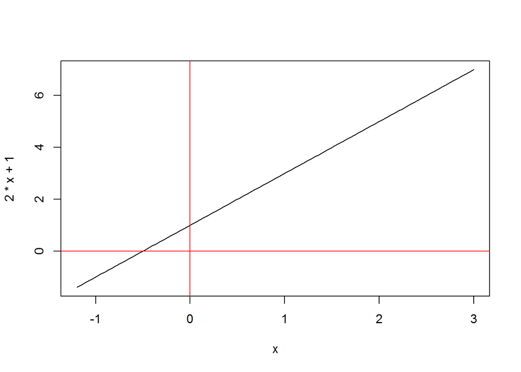

```r
curve(2*x+1,-1.2,3) # Generates the x-y graph with the line for the equation drawn in it.
abline(h=0,v=0,col="red") # Adds a horizontal line at x = 0 and a vertical line at y = 0.
```

```r
                          # Tl;dr, it adds the axes.
```

# Linear Equation (cont.)

1. General/Standard Form
   - Written as $ax + by + c = 0$ where $a$ and $b$ cannot both be 0.
   - You can convert the General/Standard Form to Point-Intercept Form using Algebra.
     - $3x + 2y - 4 = 0$
     - $2y = -3x + 4$
     - $y = (-3/2)x + 2$

# Exponents

1. An exponent is a number that indicates how many times a value should be multiplied by itself.
2. Examples:
   - $3^3 = 3 \times 3 \times 3 = 27$
   - $10^3 = 10 \times 10 \times 10 = 1,000$
   - $12^{-3} = \dfrac{1}{12^3} = 0.0005787037$
   - $4^{\frac{1}{2}} = \sqrt[2]{4} = 2$
   - $8^{\frac{1}{3}} = \sqrt[3]{8} = 2$

## Exponents in R

```r
3^3
```

```
## [1] 27
```

```r
10^3
```

```
## [1] 1000
```

```r
12^(-3)
```

```
## [1] 0.0005787037
```

```r
4^(1/2)
```

```
## [1] 2
```

```r
8^(1/3)
```

```
## [1] 2
```

1. What’s $3.14258^23$ (3.14258 raised to the 23rd power)? Type the code into R to find out!

```r
3.14258^23
```

```
- The answer you get should be 273,896,114,621.
- See how little time that took? You can use R to do lots of different math problems. No pencil, paper, frustration, or hair-pulling required.
```

2. Let’s try something interesting. What’s $37^{-3.14159}$?

```r
37^(-3.14159)
```

```
- Your result should be 1.184004e-05. But what's this "e-05" business?
```

### Scientific Notation

1. Scientific notation is used to represent very large or very small quantities.
2. You divide the number by 10 raised to a power, then note what power you raised 10 to in order to get that number. 3. For example, $1,432,000,000,000$ can be obtained by multiplying $1.432$ and $10^12$ power. To write $1,432,000,000,000$ in scientific notation, would instead write it as 1.432e12.
3. This reduces the number of characters from 13 (excluding commas) to 8.
4. It also works for numbers less than one, with $0.0000000000038$ being written as 3.8e-12.
5. For very large or very small values, this can save a lot of time and space.

## Rules of Exponents

1. $x^1 = x$
2. $x^0 = 1$
3. $x^4 \times x^{-2} = \frac{x\times x\times x\times x}{x\times x} = x^{4-2} = x^2$
4. $(x^2)^3 = (x^2)\times (x^2)\times (x^2) = (x\times x)\times (x\times x)\times (x\times x) = x^{2\times 3} = x^6$
5. $(x+y)^2 = (x+y)\times (x+y) = x^2 + x\times y + x\times y + y^2 = x^2 + 2xy + y^2$
6. $(x+y)^2 \ne x^2+y^2$
7. $(\frac{x}{y})^2 = \frac{x^2}{y^2}$

# Logarithms

1. Logarithms are related to exponents.They epresent the power which a base value must be raised in order to produce a given amount.
2. The logarithm of 8 with base 2 is 3 -Could also say: -“The log base 2 of 8 is 3.” -“The base 2 log of 8 is 3.”
3. Examples:
   $$10^2 = 100 <-> log_{10}(100) = 2$$
   $$3^4 = 81 <-> log_3(81) = 4$$

## Negative Logarithms

1. In $log_n(x)$ where $x < n$, the resulting logarithm will be negative.
   - Think back to the negative exponents from earlier. $x^1 = 1$, so we have to raise x to a value less than 1 to get n.
2. Examples:
   - What is $log_8(0.125)$?
     - Well, $\frac{1}{8} = 8^{-1} = 0.125$, so $log_8(0.125) = -1$.
   - What is $log_5(0.008)$?
     - Well, $\frac{1}{5^3} = 5^{-3} = 0.008$, so $log_5(0.008) = -3$.

## Natural Logarithms

1. The value ‘e’ is the base of the natural logarithm (Sometimes called ‘Euler’s number’).
2. It is approximately equal to 2.71828 and it’s the limit of $(1+1/n)^n$ as $n \rightarrow \infty$.
3. Logarithms of base e are often written as `ln(x)`.
   - Example: $ln(7.389) = log_e(7.389) \approx 2$
   - Because $2.71828^2 \approx 7.389$

## Logarithms in R

1. R also has a logarithm function: `log()`
   - The default base is e. R represents this value with a function `exp(x)` where ‘x’ is the power e is raised to.
   - To get e, you enter `exp(1)`

```r
log(7.389)
```

```
## [1] 1.999992
```

```r
exp(2)
```

```
## [1] 7.389056
```

2. You can specify an alternative base by defining the ‘base’ argument.

```r
log(100,base=10)
```

```
## [1] 2
```

```r
10^2
```

```
## [1] 100
```

### Properties of Logarithms

1. $log_a(xy) = log_a(x) + log_a(y)$
2. $log_a(\frac{x}{y}) = log_a(x) - log_a(y)$
3. $log_x(x) = 1$
4. $log_a(1) = 0$
5. $log_a(x^n) = n(log_a(x))$
6. $log_a(x) = \frac{1}{log_x(a)}$
7. $log_a(x) = \frac{log_b(x)}{log_b(a)} = \frac{log_{10}(x)}{log_{10}(a)}$

# Quadratic Equations

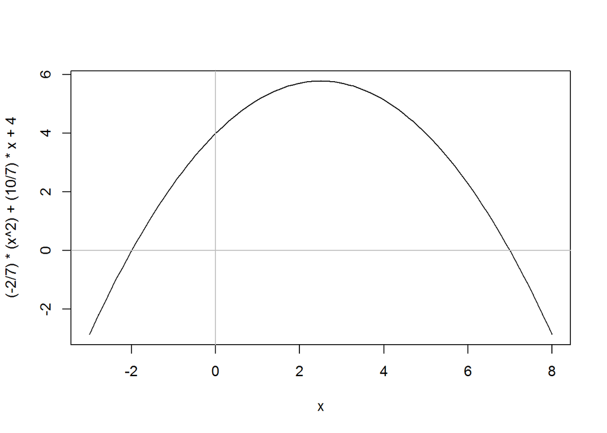

```r
curve((-2/7)*(x^2) + (10/7)*x + 4, -3,8)
abline(h=0,v=0,col="gray")
```

## Quadratic Function Example

1. Find the values of $a$, $b$, and $c$ for the following equations:
   - $2x^2 + 5x + 3 = 0$
   - $x^2 - 3x = 0$
   - $5x -3 = 0$

## Quadratic Function Example (cont.)

1. $2x^2 + 5x + 3 = 0$: In this one, a = 2, b = 5, and c = 3.
2. $x^2 - 3x = 0$: This one might be a little trickier.
   - It might be obvious that $b = -3$. What are $a$ and $c$?
   - $a = 1$. This might not be readily apparent because we don’t usually write out $1x^2$.
   - $b = -3$
   - $c = 0$, so it isn’t shown.
3. $5x -3 = 0$: This is not a quadratic equation. Remember, $a \ne 0$.

## Quadratic Formula

$$ax^2 + bx + c = 0$$
$$x^2 + \frac{b}{a}x = -\frac{c}{a}$$
$$x^2 + \frac{b}{a}x + (\frac{b}{2a})^2 = -\frac{c}{a} + (\frac{b}{2a})^2$$

- This puts the left hand side into $x^2 + 2dx + d^2$ form where $d = \frac{b}{2a}$, so we can rewrite it like this: $(x+\frac{b}{2a})^2$

$$(x + \frac{b}{2a})^2 = -\frac{c}{a} + \frac{b^2}{4a^2} = \frac{b^2-4ac}{4a^2}$$

- We then multiply the numerator and denominator of $-\frac{c}{a}$ by $4a$ so that we can merge the right-hand side into the form you see above.

$$x + \frac{b}{2a} = \frac{\pm \sqrt{b^2-4ac}}{2a}$$

NOTE: We use the $\pm$ symbol here because $(-x)^2 = x^2$, so the root could be positive or negative. Solving for x gives us:

$$x = \frac{-b \pm \sqrt{b^2-4ac}}{2a}$$

## Quadratic Formula Example (Real)

1. Solve:
   $$5x^2 + 6x + 1 = 0$$
   - Thankfully, R has a function that allows us to solve this quickly without having to do all of the work by hand.

```r
polyroot(c(1,6,5))
```

```
## [1] -0.2-0i -1.0+0i
```

### Check Answer

1. We’ll get to what the i stands for in a moment, but just take a look at those values.
   - If we set $y = 0$, then those numbers should indicate where our parabola will cross the x axis.
   - We’ll check this by graphing the curve in a similar manner to what we did earlier in this class.

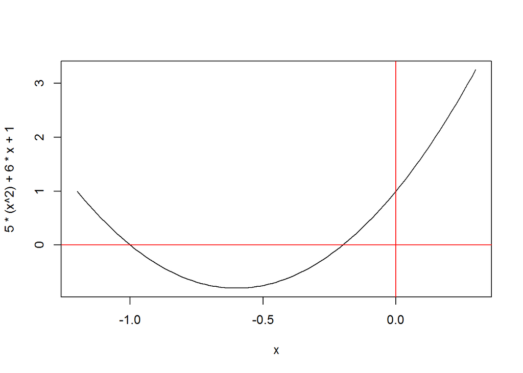

```r
curve(5*(x^2) + 6*x + 1, -1.2, 0.3)
abline(h=0,v=0,col="red")
```

## Quadratic Formula Example (Complex)

1. Solve:
   $$5x^2 + 2x + 1 = 0$$
   - As before, we’ll solve using the polyroot function.

```r
polyroot(c(1,2,5))
```

```
## [1] -0.2+0.4i -0.2-0.4i
```

# The End

Thank you. I hope you’ve found this workshop a valuable use of your time. If you’d like to study R even further, there are several excellent free resources for doing so. I’ll put them in the next slide.

# Additional resources.

1. coursera.com
   - The courses in their ‘Data Science’ certification track from Johns Hopkins University.
2. https://www.datacamp.com/
3. https://www.codeschool.com/courses/try-r
4. https://www.khanacademy.org